# Portfolio assignment

## I.Intro

### 1. Background

Lung cancer is the leading cause of cancer-related deaths these days. Non small cell lung cancer (NSCLC) accounts for approximately 80~85% of all lung cancers and is divided into 3 subtypes adenocarcinoma, squamous cell carcinoma and large cell carcinoma. The different types of NSCLC develop in different locations of the lungs. In addition, studies have shown that lung cancer in East Asia is a distinct disease characterized by a high prevalence of non-smokers, especially women, and has much more frequent EGFR-activated mutations than whites[(Chen,…(2020))](https://www.sciencedirect.com/science/article/pii/S0092867420307431#mmc4).

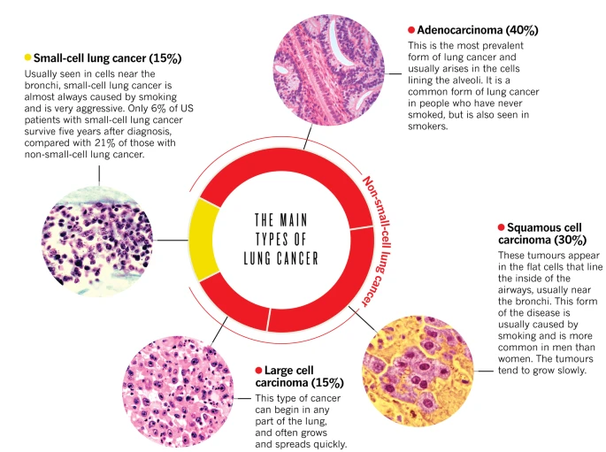

### 2. Data Visualization Topic

The purpose of this visualization is to find out which mutation EGFR gene appears differently depending on smoking status and gender. This is because EGFR mutations are most common in lung cancer patients. In addition, lung cancer is usually associated with smoking, and this paper mainly presents data on lung cancer for **non-smokers** within females.

## II. Loading the Data

### 1. Use *import* to load the excel data.

Extract tableS1A from “1-s2.0-S0092867420307431-mmc1.xlsx”

### 2. Manipulating the Data Frame

```r
library(dplyr)
library(tidyverse)
library(ggplot2)
```

```r
class(tableS1A_103patient$EGFR_Status)
```

```
[1] "character"
```

```r
table(tableS1A_103patient$`Smoking Status`)
```

```
Current_Smoker      Ex-smoker       Nonsmoke
             6             12             85
```

Expressing current smokers and ex-smokers together and non-smokers:

```r
Smk<- tableS1A_103patient %>%
  filter(`Smoking Status`!='Nonsmoke') %>% mutate(Smk = 'Y')
NonSmk<- tableS1A_103patient %>%
  filter(`Smoking Status`=='Nonsmoke') %>% mutate(Smk = 'N')
sp_t <- rbind.data.frame(Smk, NonSmk)
```

To remove ‘L858R.exon19del’ and ‘others’ in EGFR_status column:

```r
sp_t <- sp_t %>%
  filter(EGFR_Status %in% c('exon19del','L858R','WT'))
```

### 3. Draw the Plot

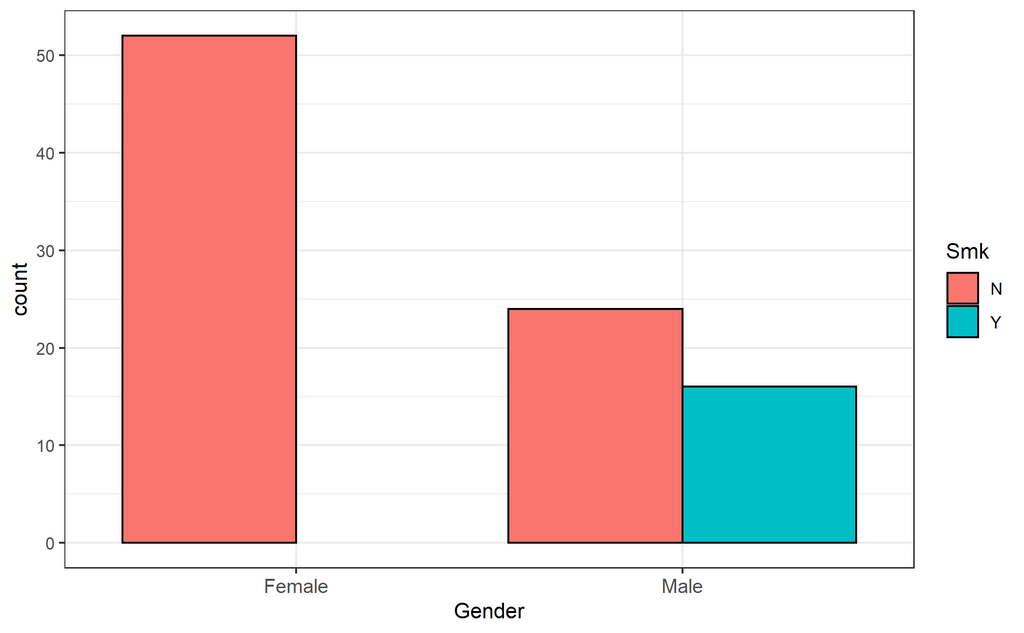

```r
#I want to have each bar to have the same width -> use 'position_dodge'

sp_t %>%
  ggplot(aes(Gender, fill=Smk))+ geom_bar(position=position_dodge(preserve = 'single'), colour="black")+
  theme_bw()+
  theme(axis.text.x=element_text(size=10))
```

## III. Discrimination

```r
WT <- sp_t%>%
  filter(EGFR_Status =='WT')%>%
  group_by(Gender, Smk)%>%
  count()%>%
  mutate(EGFR_Status ='WT')

exon19_del <- sp_t%>%
  filter(EGFR_Status =='exon19del')%>%
  group_by(Gender, Smk)%>%
  count()%>%
  mutate(EGFR_Status ='exon19_del')

L858R <- sp_t%>%
  filter(EGFR_Status =='L858R')%>%
  group_by(Gender, Smk)%>%
  count()%>%
  mutate(EGFR_Status ='L858R')
```

```r
egfr<- rbind(WT,exon19_del,L858R)
```

```r
M <- egfr %>% filter(Gender == "Male")
```

```r
Fe <- egfr %>% filter(Gender == "Female")
```

Put all the data together, ready for visualization.

```r
total<- rbind(M, Fe)
total
```

| Gender | Smk | n | EGFR_Status |
| --- | --- | --- | --- |
| Male | N | 3 | WT |
| Male | Y | 10 | WT |
| Male | N | 14 | exon19_del |
| Male | Y | 4 | exon19_del |
| Male | N | 7 | L858R |
| Male | Y | 2 | L858R |
| Female | N | 8 | WT |
| Female | N | 16 | exon19_del |
| Female | N | 28 | L858R |

```r
p <- total %>%
  ggplot(aes(n, EGFR_Status, fill=Smk))+ geom_bar(stat='identity')+
  facet_wrap(~Gender) + ggtitle('Differences in EGFR mutation between genders according to smoking status') + theme(plot.title = element_text(size = 11, face = "bold"))+
  labs(x = 'Number of samples', y='EGFR status')+
  geom_text(aes(n,label=n), position = position_stack(vjust=0.5), col="white",size=3)
```

Change the color by using `scale_fill_brewer`:

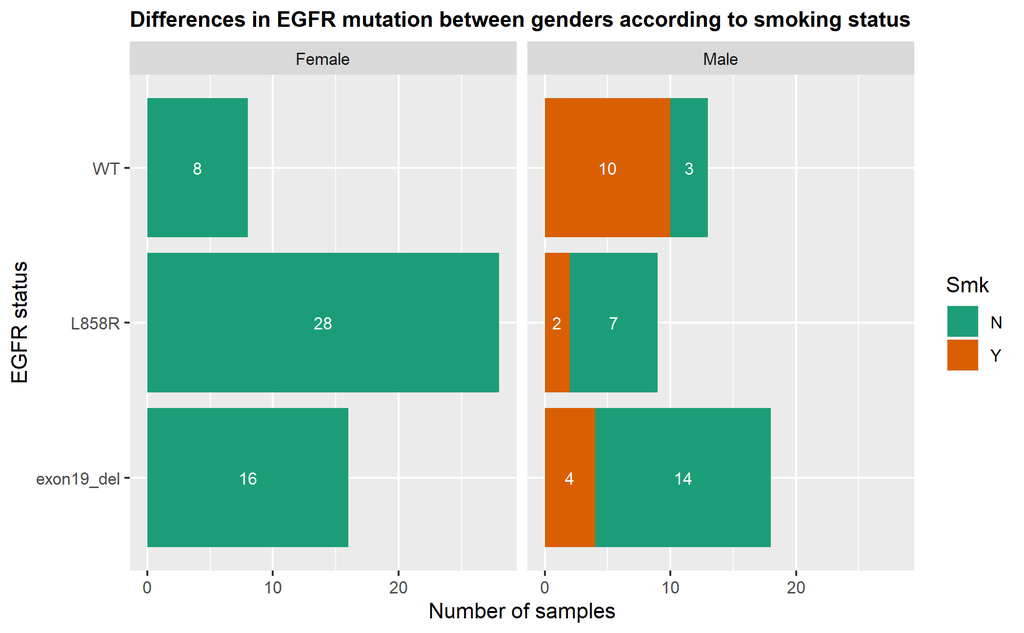

```r
p + scale_fill_brewer(palette="Dark2")
```